# Example for identical physiological rates

In the main text, we deal with a model in which $d_i = f_i = 1$ for all species. This document shows how Equations 1-4 can be integrated numerically, and how to find the equilibrium using linear programming.

```r
# load the code
source("code_identical_rates.R")
# set a random seed (optional, included here for reproducibility)
set.seed(10)
```

First, we build a random competitive network with 5 species

```r
H <- random_H(5)
print(H)
```

```
##            [,1]      [,2]      [,3]      [,4]      [,5]
## [1,] 0.50000000 0.4235897 0.6041886 0.3822132 0.9103697
## [2,] 0.57641028 0.5000000 0.6758438 0.0777307 0.5888405
## [3,] 0.39581140 0.3241562 0.5000000 0.3071466 0.6840252
## [4,] 0.61778677 0.9222693 0.6928534 0.5000000 0.2983703
## [5,] 0.08963028 0.4111595 0.3159748 0.7016297 0.5000000
```

Then, we set random initial conditions, and integrate Eq 1:

```r
x0 <- runif(5)
x0 <- x0 / sum(x0) # Sum_i x_i = 1
out_eq1 <- run_dynamics(state = x0, # initial conditions
                        maxtime = 300, # integration time
                        stepout = 0.1, # step for output
                        model = "eq1", # choose equation 1
                        H = H # matrix containing probability of winning
                        )
```

Plotting the time-series

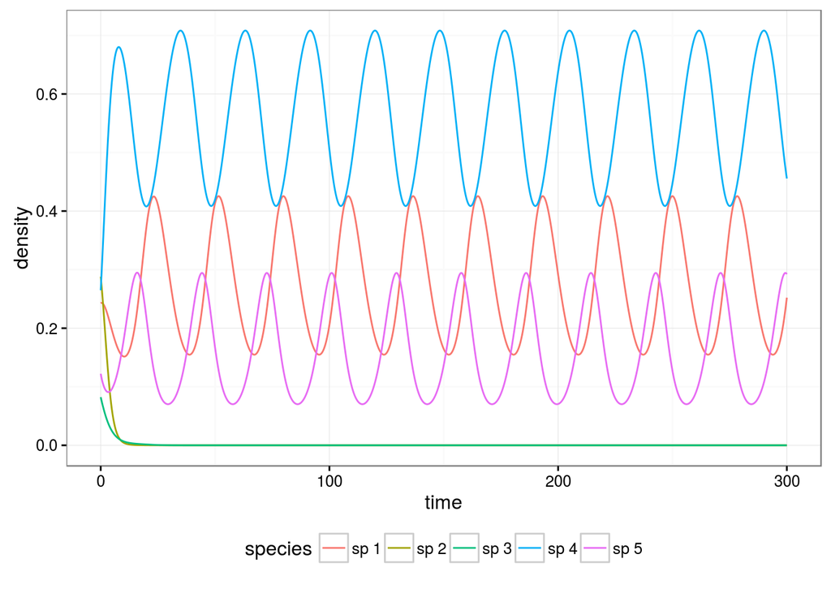

```r
show(plot_dynamics(out_eq1))
```

we see that two species went extinct, and that the remaining three are cycling. This happens irrespective of initial conditions:

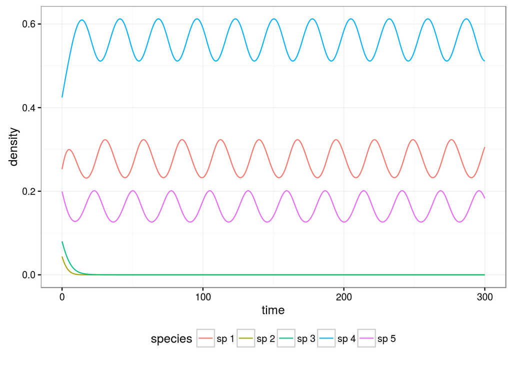

```r
x0 <- runif(5)
x0 <- x0 / sum(x0) # Sum_i x_i = 1
out_eq1_2 <- run_dynamics(state = x0, # initial conditions
                        maxtime = 300, # integration time
                        stepout = 0.1, # step for output
                        model = "eq1", # choose equation 1
                        H = H # matrix containing probability of winning
                        )
show(plot_dynamics(out_eq1_2))
```

When we integrate the system in Eq 2, we find exactly the same outcome, as the systems of equations are equivalent:

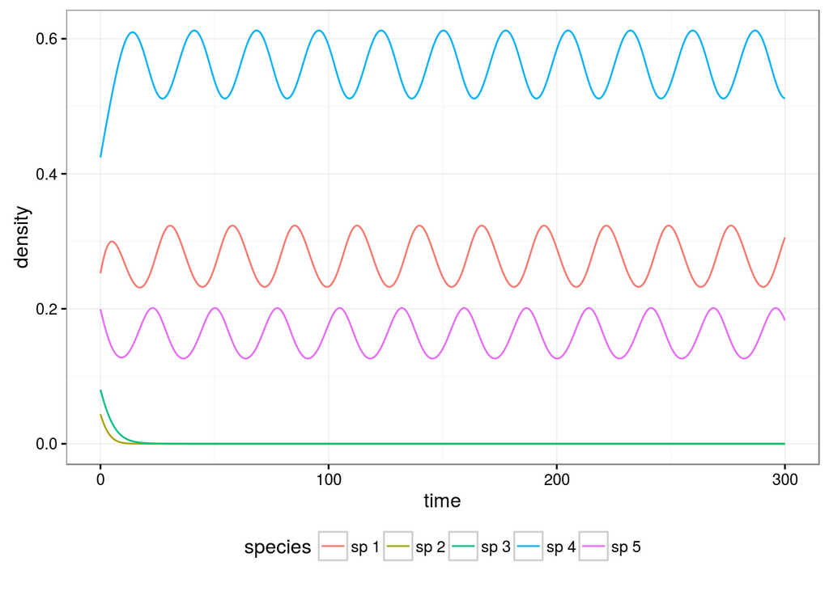

```r
out_eq2 <- run_dynamics(state = x0, # initial conditions
                        maxtime = 300, # integration time
                        stepout = 0.1, # step for output
                        model = "eq2", # equation 2: replicator equation
                        H = H # matrix containing probability of winning
                        )
show(plot_dynamics(out_eq2))
```

However, when we take three seedlings at a time, or integrate the 3-player replicator equation, dynamics converge:

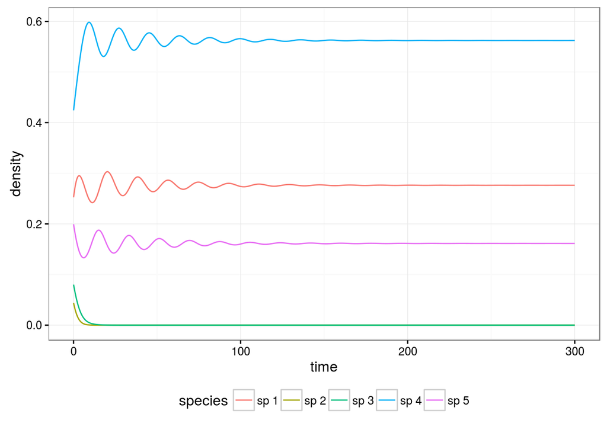

```r
out_eq3 <- run_dynamics(state = x0, # initial conditions
                        maxtime = 300, # integration time
                        stepout = 0.1, # step for output
                        model = "eq3", # equation 3: sample 3 seedlings at a time
                        H = H # matrix containing probability of winning
                        )
show(plot_dynamics(out_eq3))
```

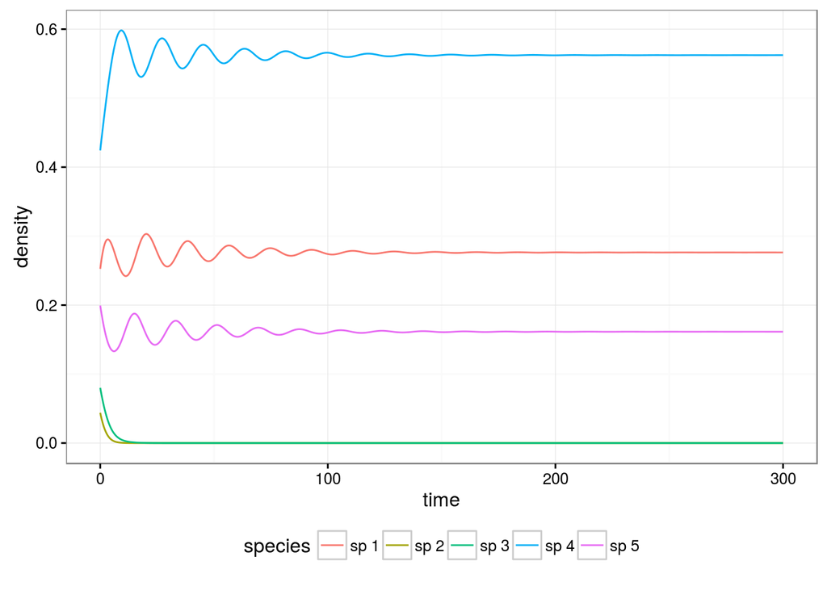

```r
out_eq4 <- run_dynamics(state = x0, # initial conditions
                        maxtime = 300, # integration time
                        stepout = 0.1, # step for output
                        model = "eq4", # equation 4: three-player replicator equation
                        H = H # matrix containing probability of winning
                        )
show(plot_dynamics(out_eq4))
```

## The equilibrium can be found using linear programming

The dynamics converge to an equilibrium, that is approximately:

```r
round(out_eq4$equil_approx, 4)
```

```
##      1      2      3      4      5
## 0.2763 0.0000 0.0000 0.5623 0.1614
```

The exact solution can be found using linear programming:

```r
round(out_eq4$equil_lp, 4)
```

```
## [1] 0.2763 0.0000 0.0000 0.5623 0.1614
```

## Starting from species-abundance distribution

We can build a matrix $H$ such that a given species abundance distribution is an equilibrium for the system of equations.

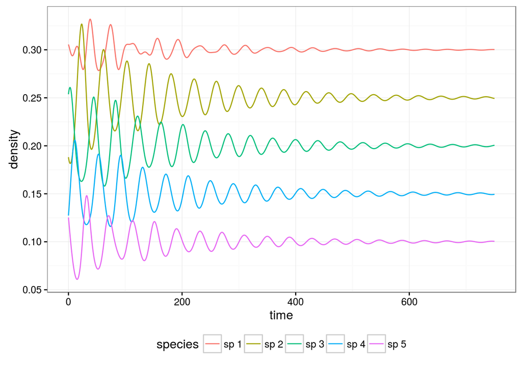

```r
target_xstar <- c(0.3, 0.25, 0.2, 0.15, 0.1)
set.seed(3)
H <- build_H_given_xstar(target_xstar)

# Now integrate dynamics
x0 <- runif(5)
x0 <- x0 / sum(x0)
out_givenx <- run_dynamics(state = x0, # initial conditions
                        maxtime = 750, # integration time
                        stepout = 0.5, # step for output
                        model = "eq4", # equation 4: three-player replicator equation
                        H = H # matrix containing probability of winning
                        )
show(plot_dynamics(out_givenx))
```